# Donor Profile: USA for UNHCR

## Transaction Volatility

USA for UNHCR funding exhibits significant volatility characterized by an average transaction value of $456,600 and 145 transactions annually, markedly below the Top 10 donor benchmark of $2.9 million and 587 transactions. This funding pattern constrains UNHCR’s capacity to strategically plan and scale emergency and resilience programs, presenting a critical opportunity for major resource mobilization. The 84% disparity in average transaction size indicates potential to consolidate and increase funding volumes, which would act as an impact multiplier by reducing administrative overhead and enabling sustained operational momentum. Investing in stabilizing and scaling transaction frequency and size with USA donors emerges as a strategic priority to unlock rapid response capabilities and enhance accountability. Immediate executive action is advised to deepen those donor relationships offering consistent high-volume contributions and to mitigate risks from irregular funding patterns. Prioritizing innovation in donor engagement and partnership optimization will leverage these insights into long-term funding stability, directly advancing UNHCR’s mandate and donor priorities.

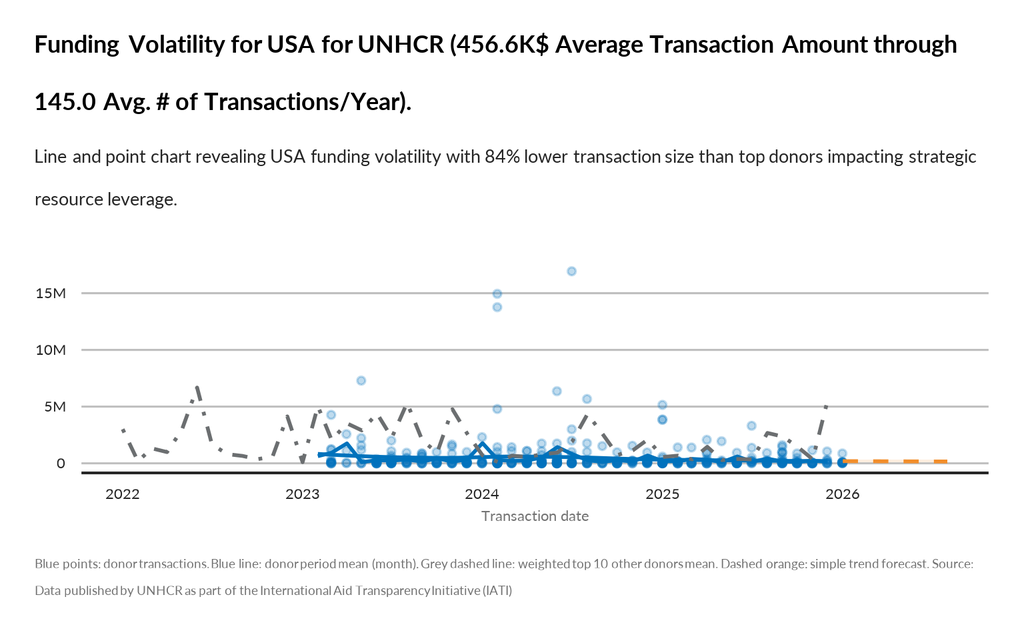

TRUE